# 3. Simulating for Probability

Stat 241

Goal: Learn how to use R to simulate flipping coins, rolling dice, and dealing cards – three common examples used in probability examples.

## Flipping coins

To simulate flipping coins, we will use two important R functions:

- `rflip(n)` simulates simulates `n` tosses of a fair coin.
- `do(n) * soemthing` repeats something `n` times. (Read it as “do n times”…)

### Example 1

Toss a fair coin 20 times. Let $X$ be the number of heads.

```r
rflip(20)
```

```
##
## Flipping 20 coins [ Prob(Heads) = 0.5 ] ...
##
## H H H H T H H T H T T H H H T T H T H T
##
## Number of Heads: 12 [Proportion Heads: 0.6]
```

Let’s do that several times

```r
do(5) * rflip(20)
```

```
##    n heads tails prop
## 1 20    13     7 0.65
## 2 20    11     9 0.55
## 3 20    11     9 0.55
## 4 20     9    11 0.45
## 5 20    13     7 0.65
```

Notice that `do()` records the information in a nice summarized format.

If we want to estimate probability, we need to repeat this many times. Let’s do it 10,000 times.

```r
Flips20 <- do(10000) * rflip(20)
```

Let’s look at the first few rows to make sure we know what we have.[^1]

```r
head(Flips20) %>% pander()
```

| n | heads | tails | prop |
| --- | --- | --- | --- |
| 20 | 8 | 12 | 0.4 |
| 20 | 9 | 11 | 0.45 |
| 20 | 8 | 12 | 0.4 |
| 20 | 8 | 12 | 0.4 |
| 20 | 7 | 13 | 0.35 |
| 20 | 16 | 4 | 0.8 |

We can let R count the number of times each value from 0 to 20 is produced by our 10000 simulations and present the information to us in a table or as a histogram

```r
tally( ~ heads, data = Flips20) %>% pander()
```

Table continues below

| 2 | 3 | 4 | 5 | 6 | 7 | 8 | 9 | 10 | 11 | 12 | 13 | 14 |
| --- | --- | --- | --- | --- | --- | --- | --- | --- | --- | --- | --- | --- |
| 2 | 10 | 42 | 136 | 375 | 756 | 1200 | 1597 | 1738 | 1581 | 1202 | 791 | 381 |

| 15 | 16 | 17 | 18 | 19 |
| --- | --- | --- | --- | --- |
| 139 | 41 | 6 | 2 | 1 |

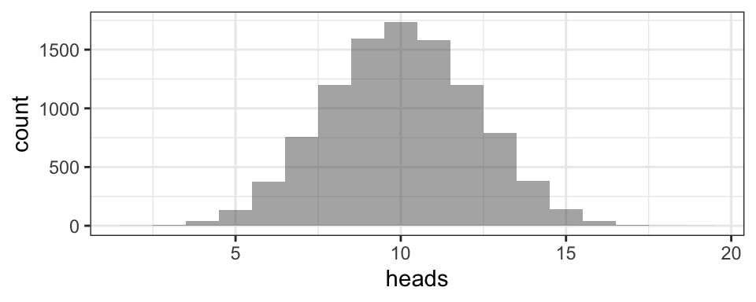

```r
gf_histogram( ~ heads, data = Flips20, binwidth = 1)
```

Perhaps we would rather have proportions rather than counts.

```r
tally( ~ heads, data = Flips20, format = "prop") %>% pander()
```

Table continues below

| 2 | 3 | 4 | 5 | 6 | 7 | 8 | 9 | 10 |
| --- | --- | --- | --- | --- | --- | --- | --- | --- |
| 2e-04 | 0.001 | 0.0042 | 0.0136 | 0.0375 | 0.0756 | 0.12 | 0.1597 | 0.1738 |

| 11 | 12 | 13 | 14 | 15 | 16 | 17 | 18 | 19 |
| --- | --- | --- | --- | --- | --- | --- | --- | --- |
| 0.1581 | 0.1202 | 0.0791 | 0.0381 | 0.0139 | 0.0041 | 6e-04 | 2e-04 | 1e-04 |

[figure not shown]

```r
gf_histogram( ~ heads, data = Flips20, binwidth = 1)
```

The table above allows to to calculate probabilities about the number of heads in 20 tosses of a fair coin.

### Example 2

Toss a biased coin 10 times and let $X$ = number of heads.  
Assume the biased coin has a probability of 0.25 of producing a head.

We simulate 10 tosses of the biased coin.

```r
rflip(10, prob = 0.25)
```

```
##
## Flipping 10 coins [ Prob(Heads) = 0.25 ] ...
##
## T T T T T H T T T H
##
## Number of Heads: 2 [Proportion Heads: 0.2]
```

Now let’s repeat that 10,000 times, find the estimated probability distribution for $X$, and make a histogram.

```r
Flips10 <- do(10000) * rflip(10, prob=.25)
tally( ~ heads, data = Flips10, format ="prop") %>% pander()
```

| 0 | 1 | 2 | 3 | 4 | 5 | 6 | 7 | 8 |
| --- | --- | --- | --- | --- | --- | --- | --- | --- |
| 0.0589 | 0.1814 | 0.2894 | 0.2501 | 0.1417 | 0.0582 | 0.017 | 0.0028 | 5e-04 |

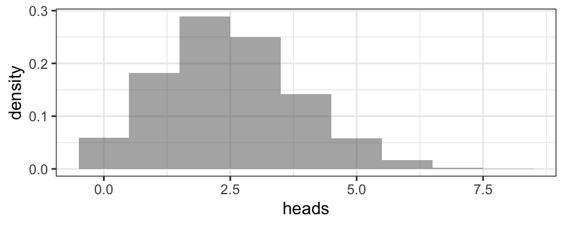

```r
gf_dhistogram( ~ heads, data = Flips10, binwidth = 1)
```

**Q.** What is (approximately) the probability of getting at least 5 heads?

We could answer this by doing the arithmetic ourselves from the table above, but we should let R do that for us. Here’s how.

```r
tally( ~(heads >= 5), data = Flips10)
```

```
## (heads >= 5)
##  TRUE FALSE
##   785  9215
```

#### Your Turn

What is the probability of getting 3 or fewer heads?

### Example 3

We can use coin tosses to simulate anything that has two possible outcomes. Here’s an example about shooting free throws.

Jo has a free throw shooting average of 85%. She has been fouled in the act of shooting a 3-point shot as time runs out. Jo has 3 free throws coming. Her team is behind by 2 points. Estimate the probability that her team does not lose in regulation time. Use 10000 simulations.

```r
FreeThrows <- do(10000) * rflip(3, prob = 0.85)
tally( ~(heads >= 2), data = FreeThrows, format = "prop")
```

```
## (heads >= 2)
##   TRUE  FALSE
## 0.9417 0.0583
```

## Rolling dice

### Example 4

Roll of a pair of fair dice. Let $S$ = sum of the results.

```r
1:6
```

```
## [1] 1 2 3 4 5 6
```

We can generate the result of tossing a fair die 10 times

```r
resample(1:6, 10)
```

```
##  [1] 1 1 4 4 2 5 3 1 2 4
```

We now simulate 10000 tosses of a fair die twice.[^2]

```r
TwoDice <-
  tibble(
    die1 = resample(1:6, 10000),
    die2 = resample(1:6, 10000),
    Sum = die1 + die2)                # add them together, componentwise
head(TwoDice) %>% pander()
```

| die1 | die2 | Sum |
| --- | --- | --- |
| 2 | 2 | 4 |
| 3 | 2 | 5 |
| 6 | 4 | 10 |
| 6 | 3 | 9 |
| 2 | 3 | 5 |
| 5 | 2 | 7 |

We create the estimated probability distribution for $S$ and the histogram.

```r
tally( ~ Sum, data = TwoDice, format = "prop") %>% pander()
```

Table continues below

| 2 | 3 | 4 | 5 | 6 | 7 | 8 | 9 | 10 |
| --- | --- | --- | --- | --- | --- | --- | --- | --- |
| 0.0261 | 0.0581 | 0.0846 | 0.1109 | 0.1395 | 0.1655 | 0.137 | 0.1121 | 0.0816 |

| 11 | 12 |
| --- | --- |
| 0.057 | 0.0276 |

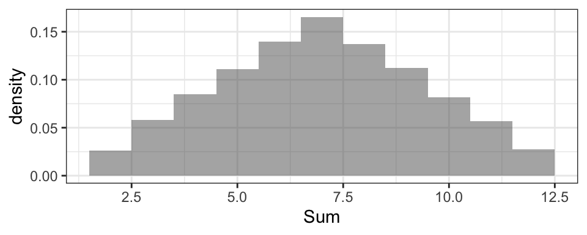

```r
gf_dhistogram( ~ Sum, data = TwoDice, binwidth = 1)
```

### Your turn

**1.** A pair of fair dice are tossed. Use 10000 simulations to estimate the probability that the dice turn up with the same value.

```r
tally( ~(die1 == die2), data = TwoDice, format = "prop") %>% pander()
```

| TRUE | FALSE |
| --- | --- |
| 0.1616 | 0.8384 |

**2.** Estimate the probability that the sum of two dice is more than 9.

```r
tally( ~(Sum > 9), data = TwoDice, format = "prop")
```

```
## (Sum > 9)
##   TRUE  FALSE
## 0.1662 0.8338
```